# Conditional Prediction

C. Lane Scher

2023-02-07

This tutorial accompanies the manuscript titled “Conditional prediction as a framework to improve predictions, understand species relationships, and inform conservation” by C. Lane Scher, Sarah Roberts, Kevin Kraus, and James S. Clark.

Here we present two examples using conditional prediction, first with simulated data, and then with data from the Breeding Bird Survey.

The conditional prediction workflow uses several updates to the `gjam` package:

- `gjamPredict()` can now make predictions that are conditioned on information about other species
- `gjamConditionalParameters()` produces the parameters associated with conditional prediction, including the species coefficient matrix

Start by loading `gjam` and `tidyverse` which will be used throughout this tutorial.

```r
library(gjam)
library(tidyverse)
```

### Simulated data

In the first example, we use simulated data. We use the gjam function `gjamSimData()` to simulate continuous data that we convert to continuous abundance data.

```r
set.seed(100)

n <- 1000   # 1000 observations
S <- 10     # 10 species
Q <- 5      # 5 predictors

sim <- gjamSimData(n = n,
                   S = S,
                   Q = Q,
                   typeNames = 'CON') # simulate continuous data
xdata <- sim$xdata
ydata <- sim$ydata
formula <- sim$formula

# convert to continuous abundance
ydata[ydata < 0] <- 0
```

We fit a GJAM with the simulated data

```r
ng <- 5000
burnin <- ng/2

modelList <- list(ng = ng, burnin = burnin, typeNames = "CA")
out <- gjam(formula = formula, xdata, ydata, modelList)
```

Now that we have the fitted model `out`, we can use it to predict. Here we’ll compare in-sample traditional and conditional prediction. The in-sample traditional predictions are already contained in `out`.

```r
# out already contains in-sample traditional predictions
trad <- out$prediction$ypredMu
```

To get the conditional predictions, we’ll iteratively treat each species as the focal species and condition on all the other species. The data to condition on is contained in the `ydataCond` within the `newdata` argument. Any combination of species can be conditioned on by assigning this argument.

```r
# make a matrix to hold the predictions
cond <- matrix(nrow = n, ncol = S)


for (s in 1:S) {

  # for focal species s:

  # condition on all species except species s
  condCols <- colnames(out$inputs$y)
  condCols <- condCols[-s]

  # predict species s
  new <- list(ydataCond = ydata[,condCols], nsim = 2000)
  cond_pred <- gjamPredict(output = out, newdata = new)

  cond[,s] <- cond_pred$sdList$yMu[,s]
}
```

[output not shown]

```r
colnames(cond) <- colnames(out$inputs$y)
```

We now have traditional predictions `trad`, conditional predictions `cond`, and true values `ydata`. We can plot them to visualize the improvement from conditioning. We’ll put the true values on the x axis, traditional predictions in red, condition predictions in blue, and the one-to-one line in black.

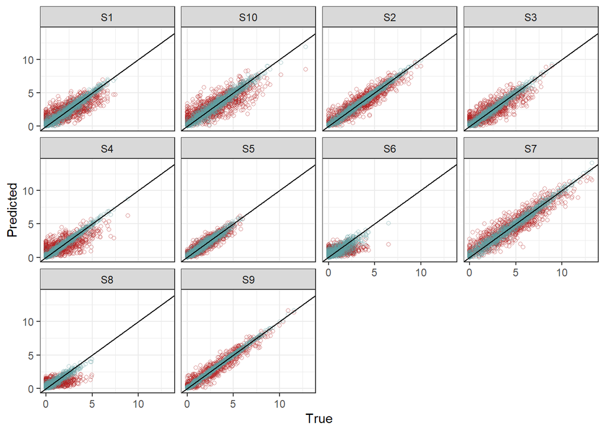

```r
trad1 <- as.data.frame(trad) %>%
  mutate(obs = 1:nrow(out$prediction$ypredMu)) %>%
  pivot_longer(!obs)

cond1 <- as.data.frame(cond) %>%
  mutate(obs = 1:nrow(out$prediction$ypredMu)) %>%
  pivot_longer(!obs)

true1 <- as.data.frame(ydata) %>%
  mutate(obs = 1:nrow(out$prediction$ypredMu)) %>%
  pivot_longer(!obs)

all <- inner_join(true1, trad1, by = c("obs", "name")) %>%
  inner_join(cond1, by = c("obs", "name"))
colnames(all)[3:5] <- c("true", "trad", "cond")

ggplot(all) +
  geom_point(aes(x = true, y = trad), color = "firebrick", alpha = 0.5,
              shape = 1) +
  geom_point(aes(x = true, y = cond), color = "cadetblue", alpha = 0.5,
              shape = 1) +
  facet_wrap(~name) +
  geom_abline(slope = 1, intercept = 0) +
  labs(x = "True", y = "Predicted") +
  theme_bw()
```

From these plots we can see that for each species the conditional predictions fall more closely along the one-to-one line.

```r
# adjust predictions for effort
truew <- out$inputs$y/out$inputs$effMat
tradw <- trad/out$inputs$effMat
condw <- cond/out$inputs$effMat


compare <- c()

for (s in 1:S) {

  # for focal species s

  # get condCols and predCols
  condCols <- colnames(out$inputs$y)
  condCols <- condCols[-s]

  predCols <- colnames(out$inputs$y)[s]

  # get spe
  coni <- (truew[,predCols] - condw[,predCols] )^2
  unci <- (truew[,predCols] - tradw[,predCols] )^2

  # how many spe are greater for traditional prediction
  umc  <- unci - coni
  uno  <- length(which(umc > 0))/length(umc)  # fraction larger error in uncon

  # get rmspe
  rmspecond <- sqrt(mean(coni))
  rmspetrad <- sqrt(mean(unci))


  # add to compare dataframe
  compare <- rbind(compare, c(rmspetrad, rmspecond,
                              (rmspetrad-rmspecond) * 100, uno))
}
colnames(compare) <- c("Unc RMSPE", "Con RMSPE", "Perc Diff", "Frac u > c")
print(compare)
```

```
##       Unc RMSPE Con RMSPE Perc Diff Frac u > c
##  [1,] 1.0709552 0.4011119  66.98432      0.821
##  [2,] 0.8145901 0.2646946  54.98955      0.832
##  [3,] 0.9368197 0.2770150  65.98047      0.860
##  [4,] 1.0306685 0.2271630  80.35055      0.878
##  [5,] 0.5367527 0.2928600  24.38928      0.732
##  [6,] 0.8532425 0.4834788  36.97637      0.752
##  [7,] 1.0428263 0.4003340  64.24923      0.785
##  [8,] 0.8149652 0.2666833  54.82818      0.874
##  [9,] 0.5944163 0.1292830  46.51333      0.848
## [10,] 1.2823825 0.4523504  83.00321      0.820
```

`compare` contains several metrics to evaluate the improvement that comes from conditioning:

- Unc RMSPE: RMSPE for unconditional prediction
- Con RMSPE: RMSPE for conditional prediction
- Perc Diff: percent difference between unconditional and conditional prediction (positive value indicates improvement from conditioning)
- Frac u > c: fraction of unconditional predictions whose error is greater than the corresponding conditional predictions (value above 0.5 indicates improvement from conditioning)

Across species, we see that conditional predictions are better than traditional prediction, in terms of both percent difference in RMSPE (Perc Diff) and in the percent of predictions that are improved by conditioning (Frac u > c).

Last, we can look at the relationships between abundances of species. We do this using `gjamConditionalParameters()`. Again, we iteratively treat each species as the focal species. Here, the species to condition on are entered in the `conditionOn` argument.

```r
speciesCoefficients <- c()

for (s in 1:S) {

  # for focal species s:

  # condition on all species except species s
  condCols <- colnames(out$inputs$y)
  condCols <- condCols[-s]

  # compare predictions of species s
  param <- gjamConditionalParameters(output = out, conditionOn = condCols, nsim = 2000)
  Atab <- param$Atab %>%
    mutate(condOn = condCols, # species conditioned on
           predSpecies = colnames(out$inputs$y)[s])   # species predicted

  # add to compare dataframe
  speciesCoefficients <- rbind(speciesCoefficients, Atab)
}
```

In `speciesCoefficients$Estimate`, we can see the information added by each species conditioned on (`speciesCoefficients$condOn`) to each species predicted (`speciesCoefficients$predSpecies`).

We can convert that to matrix form, where `speciesCoefMatrix[1,2]` is the information from `S2` added to predictions of `S1` (i.e., `S1` is predicted conditionally on `S2`).

```r
speciesCoefMatrix <- speciesCoefficients %>%
  select(Estimate, condOn, predSpecies) %>%
  pivot_wider(values_from = Estimate, names_from = condOn) %>%
  select(predSpecies, S1, everything()) %>%
  as.data.frame()
rownames(speciesCoefMatrix) <- speciesCoefMatrix$predSpecies
speciesCoefMatrix$predSpecies <- NULL

print(speciesCoefMatrix)
```

```
##          S1      S2       S3      S4       S5       S6       S7       S8
## S1       NA  1.3390  0.77230  1.0360  0.11630 -0.40740 -0.66140  0.13070
## S2   0.5912      NA -0.41480 -0.6972 -0.05180  0.26170  0.41630 -0.03660
## S3   0.5675 -0.6915       NA -0.1217  0.07651  0.06448  0.32490 -0.52180
## S4   0.4502 -0.6852 -0.07299      NA -0.27640  0.30410  0.45680  0.16700
## S5   0.1068 -0.1070  0.09444 -0.5816       NA  0.12800  0.01863  0.39630
## S6  -1.2100  1.7570  0.25990  2.0780  0.41580       NA -0.98010 -0.60510
## S7  -0.8566  1.2230  0.57040  1.3660  0.02687 -0.42900       NA  0.12200
## S8   0.1625 -0.1037 -0.89430  0.4884  0.54790 -0.25850  0.12100       NA
## S9  -0.3010  0.4994  0.16360  0.5491  0.20080 -0.16120 -0.24740 -0.03678
## S10  1.0660 -1.5030 -1.05000 -0.7173  0.17000  0.44050  0.75370 -0.12800
##          S9      S10
## S1  -1.8340  0.57630
## S2   1.3430 -0.35890
## S3   0.7331 -0.41730
## S4   1.4500 -0.16890
## S5   1.1150  0.08222
## S6  -2.9140  0.70650
## S7  -1.9550  0.52780
## S8  -0.2859 -0.08595
## S9       NA  0.12110
## S10  1.3670       NA
```

### Real data

First, load the data and fit a gjam. Change `pathToData` to wherever you saved the downloaded data.

```r
pathToData <- "X:/conditionalPrediction/DATA/birds/"

# load data
load(paste0(pathToData, "covar.rdata"))
load(paste0(pathToData, "counts.rdata"))

# inner join to get sites where we have counts and covariates
all <- counts %>%
  inner_join(covar, by = "idYear")

# separate x and y
y <- all[,2:18]
x <- all[,c(1, 19, 27:28, 20:25, 29, 46:53)]

# formula
formulaI <- as.formula(~ elevation +
                         prcpMean + prcpAnom +
                         tminMean + tminAnom +
                         forest + developed + water + wetlands + planted + shrub + herbaceous)

# set up gjam
effort <- list(columns=1:ncol(y), values = 150) # 150 minutes per BBS route

ng <- 3000
burnin <- ng/2
ml   <- list(ng = ng, burnin = burnin, typeNames = "DA",
             effort = effort)

# run gjam
out <- gjam(formulaI, xdata = x, ydata = y, modelList = ml)
```

We can look at the predictions, comparing traditional to conditional predictions. We’ll just look at a few of the species (those listed in `spUse`).

```r
spUse <- c("kirtlandswarbler", "chippingsparrow", "brownheadedcowbird")

### traditional prediction
trad <- out$prediction$ypredMu


### conditional prediction
# make a matrix to hold the predictions
cond <- matrix(nrow = nrow(out$inputs$xdata), ncol = length(spUse))

for (s in 1:length(spUse)) {

  # condition on all species except species s
  condCols <- colnames(out$inputs$y)
  condCols <- condCols[-grep(spUse[s], condCols)]

  # predict species s
  new <- list(ydataCond = out$inputs$y[,condCols], nsim = 2000)
  cond_pred <- gjamPredict(output = out, newdata = new)

  cond[,s] <- cond_pred$sdList$yMu[,spUse[s]]
}
colnames(cond) <- spUse
```

Plot it.

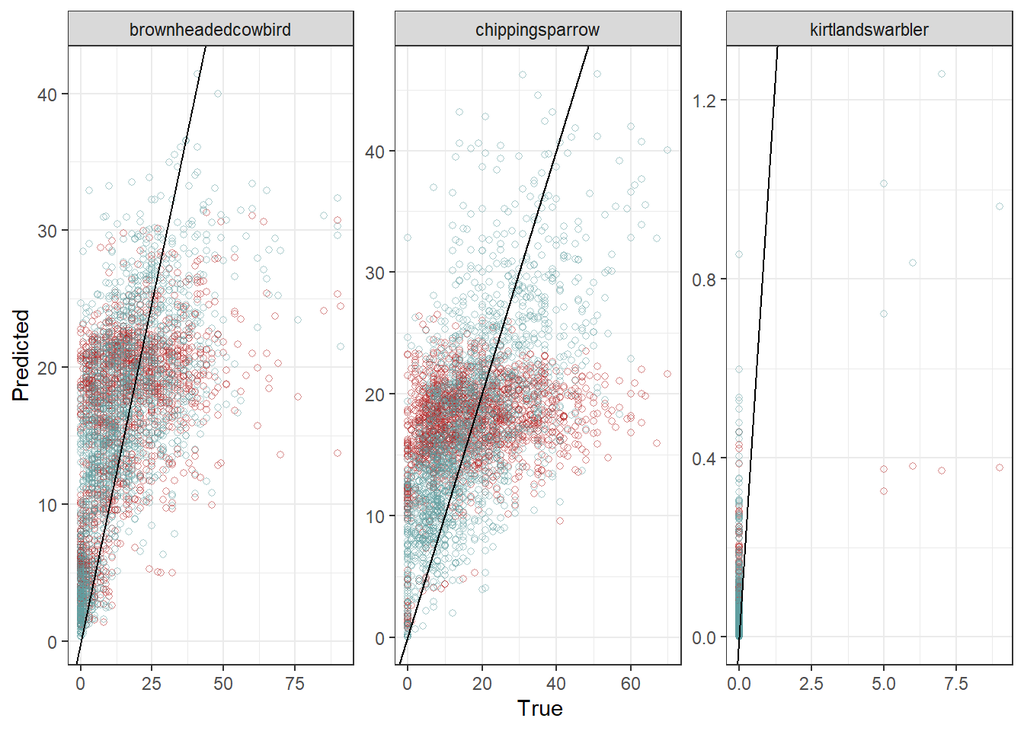

```r
trad1 <- as.data.frame(trad) %>%
  mutate(obs = 1:nrow(out$prediction$ypredMu)) %>%
  pivot_longer(!obs) %>%
  filter(name %in% spUse)

cond1 <- as.data.frame(cond) %>%
  mutate(obs = 1:nrow(out$prediction$ypredMu)) %>%
  pivot_longer(!obs)

true1 <- as.data.frame(y) %>%
  mutate(obs = 1:nrow(out$prediction$ypredMu)) %>%
  pivot_longer(!obs) %>%
  mutate(name = gsub(" |'|-", "", name)) %>%
  filter(name %in% spUse)

all <- inner_join(true1, trad1, by = c("obs", "name")) %>%
  inner_join(cond1, by = c("obs", "name"))
colnames(all)[3:5] <- c("true", "trad", "cond")

ggplot(all) +
  geom_point(aes(x = true, y = trad), color = "firebrick", alpha = 0.5,
              shape = 1) +
  geom_point(aes(x = true, y = cond), color = "cadetblue", alpha = 0.5,
              shape = 1) +
  facet_wrap(~name, scales = "free") +
  geom_abline(slope = 1, intercept = 0) +
  labs(x = "True", y = "Predicted") +
  theme_bw()
```

Quantify the improvement from conditioning.

```r
# adjust predictions for effort
truew <- out$inputs$y/out$inputs$effMat
tradw <- trad/out$inputs$effMat
condw <- cond/out$inputs$effMat[,grep(spUse, colnames(out$inputs$effMat))]


compare <- c()
for (s in 1:length(spUse)) {

  # get condCols and predCols
  condCols <- colnames(out$inputs$y)
  condCols <- condCols[-grep(spUse[s], condCols)]

  predCols <- spUse[s]

  # get spe
  coni <- (truew[,predCols] - condw[,predCols] )^2
  unci <- (truew[,predCols] - tradw[,predCols] )^2

  # how many spe are greater for traditional prediction
  umc  <- unci - coni
  uno  <- length(which(umc > 0))/length(umc)  # fraction larger error in uncon

  # get rmspe
  rmspecond <- sqrt(mean(coni))
  rmspetrad <- sqrt(mean(unci))


  # add to compare dataframe
  compare <- rbind(compare, c(rmspetrad, rmspecond,
                              (rmspetrad-rmspecond) * 100, uno))
}
colnames(compare) <- c("Unc RMSPE", "Con RMSPE", "Perc Diff", "Frac u > c")
print(compare)
```

```
##        Unc RMSPE   Con RMSPE  Perc Diff Frac u > c
## [1,] 0.002188891 0.002005603 0.01832885  0.7341357
## [2,] 0.080635209 0.063669190 1.69660194  0.6838074
## [3,] 0.077025886 0.070381900 0.66439863  0.5935449
```

Finally, look at the species coefficients.

```r
speciesCoefficients <- c()
for (s in 1:length(spUse)) {

  # condition on all species except species s
  condCols <- colnames(out$inputs$y)
  condCols <- condCols[-grep(spUse[s], condCols)]

  # compare predictions of species s
  param <- gjamConditionalParameters(output = out, conditionOn = condCols, nsim = 2000)
  Atab <- param$Atab %>%
    mutate(condOn = condCols, # species conditioned on
           predSpecies = spUse[s])   # species predicted

  # add to compare dataframe
  speciesCoefficients <- rbind(speciesCoefficients, Atab)
}

# keep only species of interest (those in spUse)
speciesCoefficients <- speciesCoefficients %>%
  filter(condOn %in% spUse)

speciesCoefMatrix <- speciesCoefficients %>%
  select(Estimate, condOn, predSpecies) %>%
  pivot_wider(values_from = Estimate, names_from = condOn)%>%
  select(predSpecies, spUse[1], everything()) %>%
  as.data.frame()
rownames(speciesCoefMatrix) <- speciesCoefMatrix$predSpecies
speciesCoefMatrix$predSpecies <- NULL

print(speciesCoefMatrix)
```

```
##                    kirtlandswarbler chippingsparrow brownheadedcowbird
## kirtlandswarbler                 NA         0.02365           -0.01554
## chippingsparrow               6.275              NA            0.24760
## brownheadedcowbird           -5.895         0.36390                 NA
```